# Digoxin Model

Ben Ridenhour

25-Aug-21

## A Simple Analysis of Digoxin Based on Weight and Time

Given a data set containing 4 variables (subject ID, visit date, weight, and the mM concentration of digoxin), we have been asked to create a simple baseline metabolic model for digoxin in the blood. We have been told two facts: First, digoxin changes proportionally to changes in weight. Second, digoxin level are known fluctuate in a roughly thirty day cycle. Details of our analysis are given below.

## Data Processing

First we read in the data and verify it.

```r
digoxin <- read.csv("Digoxin.csv", header = T)

str(digoxin)
```

```
'data.frame':   60 obs. of  4 variables:
 $ Subject   : chr  "Bob" "Bob" "Bob" "Bob" ...
 $ Visit     : chr  "1/7/19" "1/14/19" "1/21/19" "1/28/19" ...
 $ Weight    : chr  "70_" "70.14274607" "69.93259171" "69.50474495" ...
 $ mM_Digoxin: num  8.8 9.3 8.34 8.32 8.44 ...
```

```r
digoxin$Visit <- as.Date(digoxin$Visit, format = "%m/%d/%y")
```

Next, we need to fix the weight variable. First, look at the data frame. We’ll use the `xtable` library to make things look nice. We need to load the library:

```r
library(xtable)
```

Then run:

```r
#print first 10 lines only
print(xtable(head(digoxin,10), align = c("l","c","c","r","r")),
      type="html", include.rownames=FALSE)
```

| Subject | Visit | Weight | mM_Digoxin |
| --- | --- | --- | --- |
| Bob | 17903.00 | 70_ | 8.80 |
| Bob | 17910.00 | 70.14274607 | 9.30 |
| Bob | 17917.00 | 69.93259171 | 8.34 |
| Bob | 17924.00 | 69.50474495 | 8.32 |
| Bob | 17931.00 | 69.12012598 | 8.44 |
| Bob | 17938.00 | 69.33239468 | 8.73 |
| Bob | 17945.00 | 68.65070198 | 8.64 |
| Bob | 17952.00 | 69.6176188 | 8.41 |
| Bob | 17959.00 | 70.27932023 | 8.60 |
| Bob | 17966.00 | 71.01039185 | 9.19 |

Clearly the first row has an improperly formatted weight, so we have to fix that.

```r
#First change a factor to a character vector, then a numeric one
digoxin$Weight <- as.numeric(as.character(digoxin$Weight))
#Next, the first element of the vector is now NA due to the improper formating; fix this by
#inserting the proper value
digoxin$Weight[1] <- 70
#Finally, check the structure again:
str(digoxin)
```

```
'data.frame':   60 obs. of  4 variables:
 $ Subject   : chr  "Bob" "Bob" "Bob" "Bob" ...
 $ Visit     : Date, format: "2019-01-07" "2019-01-14" "2019-01-21" ...
 $ Weight    : num  70 70.1 69.9 69.5 69.1 ...
 $ mM_Digoxin: num  8.8 9.3 8.34 8.32 8.44 ...
```

Our data now look good!

## Plot the Data

Before analyzing the data, let’s plot it to get a feel for it. We’ll use `ggplot2` for this task.

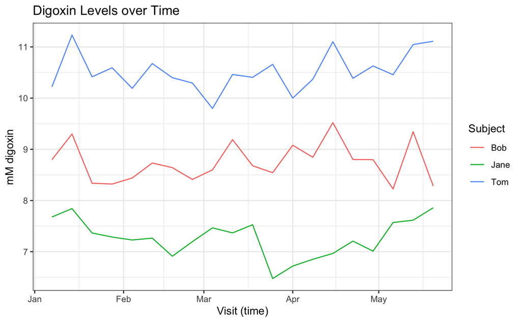

## Some Possible Models

We were given to facts about our data that indicate that

$$y = a + b_1 x_1 + b_2 sin(\frac{2 \pi}{30} x_2)$$

is a reasonable model for digoxin, where $y = [digoxin]$, $x_1 = weight$, and $x_2=time$. We will run two versions of the model. In the first version, we estimate the parameter $a$; in the second version, $a=0$.

```r
m1 <- lm(mM_Digoxin ~ Weight + I(sin(2*pi/30*as.numeric(Visit))), data=digoxin)
summary(m1)
```

```
Call:
lm(formula = mM_Digoxin ~ Weight + I(sin(2 * pi/30 * as.numeric(Visit))),
    data = digoxin)

Residuals:
     Min       1Q   Median       3Q      Max
-0.66477 -0.26863  0.01734  0.18702  0.74500

Coefficients:
                                      Estimate Std. Error t value Pr(>|t|)
(Intercept)                           0.047777   0.291800   0.164    0.871
Weight                                0.124981   0.004098  30.497   <2e-16 ***
I(sin(2 * pi/30 * as.numeric(Visit))) 0.015859   0.060766   0.261    0.795
---
Signif. codes:  0 ‘***’ 0.001 ‘**’ 0.01 ‘*’ 0.05 ‘.’ 0.1 ‘ ’ 1

Residual standard error: 0.3398 on 57 degrees of freedom
Multiple R-squared:  0.9423,    Adjusted R-squared:  0.9402
F-statistic:   465 on 2 and 57 DF,  p-value: < 2.2e-16
```

```r
m2 <- lm(mM_Digoxin ~ Weight + I(sin(2*pi/30*as.numeric(Visit))) - 1, data=digoxin)
summary(m2)
```

```
Call:
lm(formula = mM_Digoxin ~ Weight + I(sin(2 * pi/30 * as.numeric(Visit))) -
    1, data = digoxin)

Residuals:
     Min       1Q   Median       3Q      Max
-0.65462 -0.27045  0.01307  0.19666  0.74645

Coefficients:
                                      Estimate Std. Error t value Pr(>|t|)
Weight                                0.125645   0.000611 205.652   <2e-16 ***
I(sin(2 * pi/30 * as.numeric(Visit))) 0.015930   0.060253   0.264    0.792
---
Signif. codes:  0 ‘***’ 0.001 ‘**’ 0.01 ‘*’ 0.05 ‘.’ 0.1 ‘ ’ 1

Residual standard error: 0.337 on 58 degrees of freedom
Multiple R-squared:  0.9986,    Adjusted R-squared:  0.9986
F-statistic: 2.115e+04 on 2 and 58 DF,  p-value: < 2.2e-16
```

### Comparing models using ANOVA

We can ask R which of our two models might be a better choice using the `ANOVA` function. Let’s do that and then plot the diagnostics of the better model.

```r
anova(m1,m2) #m2 would be favored
```

```
Analysis of Variance Table

Model 1: mM_Digoxin ~ Weight + I(sin(2 * pi/30 * as.numeric(Visit)))
Model 2: mM_Digoxin ~ Weight + I(sin(2 * pi/30 * as.numeric(Visit))) -
    1
  Res.Df    RSS Df  Sum of Sq      F Pr(>F)
1     57 6.5821
2     58 6.5852 -1 -0.0030957 0.0268 0.8705
```

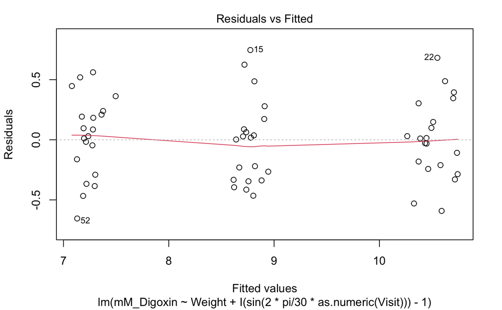

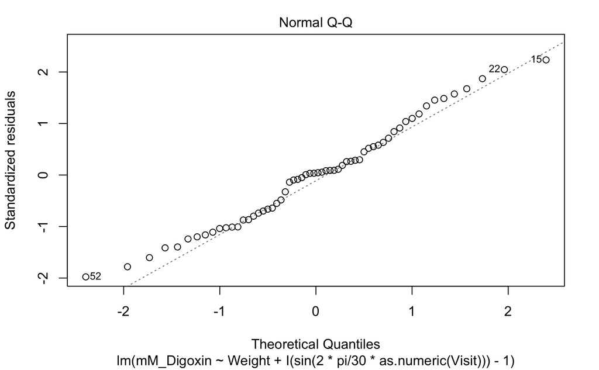

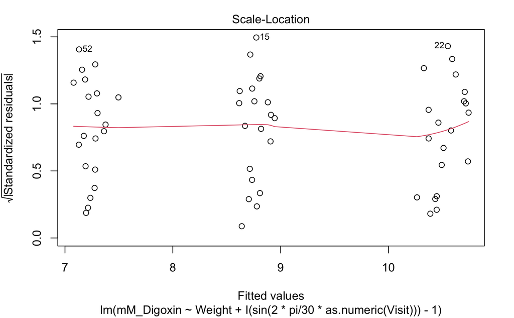

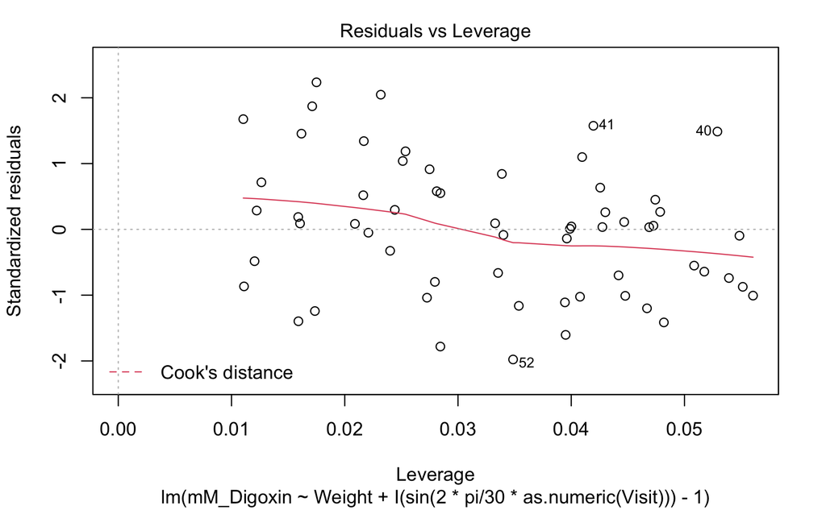

```r
plot(m2)
```

The ANOVA tells us the model without an intercept is better; the diagnostics for this model look good.